#### 5

This problem asks you to compare the latest date in each winter when there was at least one inch of snow for two different time periods using the official Madison weather data

-5a. Create a data set with the latest date from January to June in each year where there was at least one inch of snow for the years 1901–1920 and 2001–2020. - Use the **lubridate** function `yday()` to create a new variable `yday` by converting this date into the number of days after December 31. - Add a variable named `period` which has the value `"early 1900s"` for years 1901–1920 and `"early 2000s"` for the years 2001–2020.

```r
library(dplyr)
library(lubridate)

# Read the data
data5 <- read.csv("../../data/madison-weather-official-1869-2023.csv")

# Extract year, month, and day from the date column
data5 <- data5 %>%
  mutate(year = year(date),
         month = month(date),
         day = day(date))

# Filter data for the specified time periods (1901-1920 and 2001-2020)
data_1901_1920 <- data5 %>%
  filter(year >= 1901 & year <= 1920)

data_2001_2020 <- data5 %>%
  filter(year >= 2001 & year <= 2020)

# Extract latest date with at least one inch of snow for each winter (January to June)
latest_snow_1901_1920 <- data_1901_1920 %>%
  filter(month %in% 1:6 & snow >= 1) %>%
  group_by(year) %>%
  summarize(latest_date = max(date))

latest_snow_2001_2020 <- data_2001_2020 %>%
  filter(month %in% 1:6 & snow >= 1) %>%
  group_by(year) %>%
  summarize(latest_date = max(date))

# Combine the datasets and add the 'period' variable
combined_data <- rbind(latest_snow_1901_1920, latest_snow_2001_2020)
combined_data$period <- ifelse(combined_data$year %in% 1901:1920, "early 1900s", "early 2000s")

# Convert latest_date to day of year using lubridate::yday()
combined_data$yday <- yday(combined_data$latest_date)

# View the final dataset
combined_data
```

```
## # A tibble: 39 × 4
##     year latest_date period       yday
##    <dbl> <chr>       <chr>       <dbl>
##  1  1901 1901-03-10  early 1900s    69
##  2  1903 1903-04-21  early 1900s   111
##  3  1904 1904-03-14  early 1900s    74
##  4  1905 1905-04-21  early 1900s   111
##  5  1906 1906-04-05  early 1900s    95
##  6  1907 1907-04-07  early 1900s    97
##  7  1908 1908-02-19  early 1900s    50
##  8  1909 1909-03-09  early 1900s    68
##  9  1910 1910-04-23  early 1900s   113
## 10  1911 1911-04-06  early 1900s    96
## # ℹ 29 more rows
```

-5b. Calculate the sample size, the sample mean, and the sample standard deviation for each period.

```r
table5 = combined_data %>%
  group_by(period) %>%
  summarize(averageYday = mean(yday), sdYday = sd(yday), n = n())
table5
```

```
## # A tibble: 2 × 4
##   period      averageYday sdYday     n
##   <chr>             <dbl>  <dbl> <int>
## 1 early 1900s        83.4   19.1    19
## 2 early 2000s        90.8   15.9    20
```

```r
xbar = table5$averageYday[1]
ybar = table5$averageYday[2]
sx = table5$sdYday[1]
sy = table5$sdYday[2]
nx = table5$n[1]
ny = table5$n[2]

se = sqrt(sx^2/nx + sy^2/ny)
se
```

```
## [1] 5.645812
```

```r
test_stat = ((ybar-xbar) - 0)/se
test_stat
```

```
## [1] 1.325156
```

-5c. Create a graph to compare these two distributions.

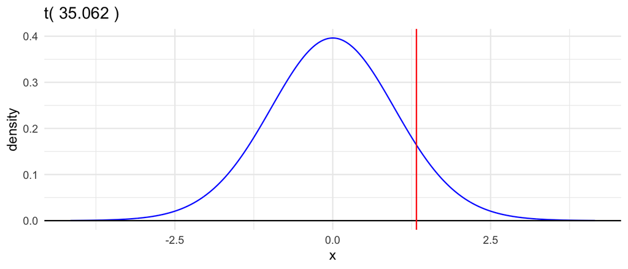

```r
W = (sx^2/nx + sy^2/ny)^2 / (sx^4/(nx^2*(nx-1)) + sy^4/(ny^2*(ny-1)))

gt(df = W) +
  geom_vline(xintercept = test_stat, color = "red")
```

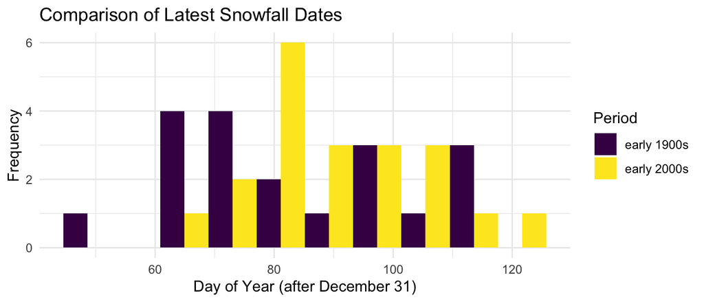

```r
ggplot(combined_data, aes(x = yday, fill = period)) +
  geom_histogram(position = "dodge", bins = 10) +
  labs(title = "Comparison of Latest Snowfall Dates",
       x = "Day of Year (after December 31)",
       y = "Frequency",
       fill = "Period") +
  theme_minimal()
```

```r
qnorm(0.975) #just to compare
```

```
## [1] 1.959964
```

```r
qt(0.975, df = W)
```

```
## [1] 2.02998
```

#### 6

Using the data from the previous problem:

-6a. Use `t.test()` to construct a confidence interval for the difference in the mean last day of at least one inch of snow between these two time periods.

```r
test_data_1900 = combined_data %>%
  filter(period == "early 1900s")
test_data_2000 = combined_data %>%
  filter(period == "early 2000s")

t.test(test_data_1900["yday"], test_data_2000["yday"])
```

```
##
##  Welch Two Sample t-test
##
## data:  test_data_1900["yday"] and test_data_2000["yday"]
## t = -1.3252, df = 35.062, p-value = 0.1937
## alternative hypothesis: true difference in means is not equal to 0
## 95 percent confidence interval:
##  -18.942465   3.979307
## sample estimates:
## mean of x mean of y
##  83.36842  90.85000
```

-6b. Interpret the confidence interval in context.

> We fail to find evidence for a difference between the true underlying 1900s and 2000s last days with more than 1 inch show.

-6c. Use `t.test()` to test the hypothesis that the population mean last day of at least one inch of snow are identical in the two time periods versus the alternative that they are different.

```r
(1 - pt(test_stat, W)) * 2
```

```
## [1] 0.1936908
```

```r
t.test(test_data_1900["yday"], test_data_2000["yday"])
```

```
##
##  Welch Two Sample t-test
##
## data:  test_data_1900["yday"] and test_data_2000["yday"]
## t = -1.3252, df = 35.062, p-value = 0.1937
## alternative hypothesis: true difference in means is not equal to 0
## 95 percent confidence interval:
##  -18.942465   3.979307
## sample estimates:
## mean of x mean of y
##  83.36842  90.85000
```

-6d. We fail to find evidence for a difference between the true underlying 1900s and 2000s mean last day with +1 inch of snow.(0.1937).

#### 7

Using the Boston Marathon data, treat the finishing times of men aged 35–39 in 2010 as a sample from a larger population of men worldwide who could have completed the Boston marathon that year.

-7a. Calculate a numerical summary of the times to finish the race from this sample, including the sample size, sample mean, sample standard deviation, and the 0.10, 0.25, 0.50, 0.75, and 0.90 quantiles.

```r
data7 <- read.csv("../../data/boston-marathon-data.csv")

data_men = data7 %>%
  filter(Sex == "male") %>%
  filter(Year == 2010) %>%
  filter(Age>=35 & Age<=39)

data_men2 = data_men %>%
  summarize(n = n(),
            min = min(Time),
            q10 = quantile(Time, 0.10),
            q25 = quantile(Time, 0.25),
            mean = mean(Time),
            median = median(Time),
            q75 = quantile(Time, 0.75),
            q90 = quantile(Time, 0.90),
            max(Time),
            sd(Time)) %>%
  print(n = Inf)
```

[output not shown]

-7b. Choose a type of graph and display the distribution of the sample finish times.

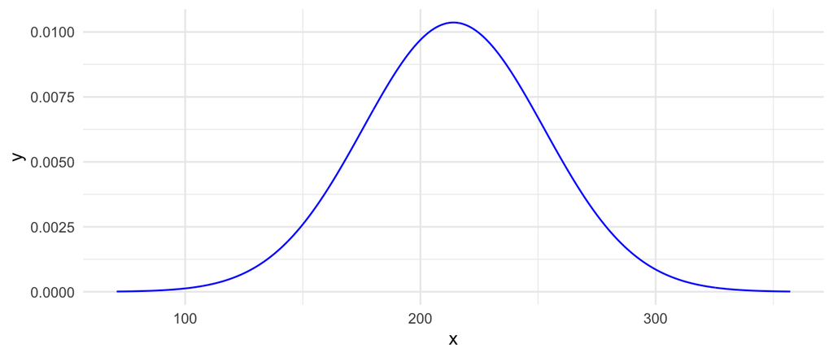

```r
ggplot() +
  geom_norm_density(mu = 214.058, sigma = 38.49504, color = "blue")
```

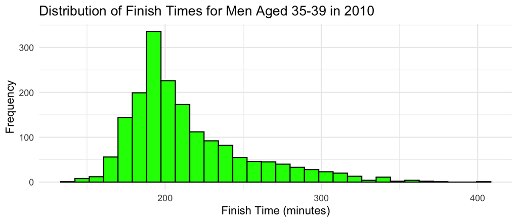

```r
ggplot(data_men, aes(x = Time)) +
  geom_histogram(fill = "green", color = "black") +
  labs(title = "Distribution of Finish Times for Men Aged 35-39 in 2010",
       x = "Finish Time (minutes)",
       y = "Frequency")
```

-7c. Find a 95% confidence interval for the mean finishing time in the population using methods of the t distribution by direct calculation

```r
c = 0.95
mu = qt(c + (1-c)/2, df = 1769-1) * data_men2["sd(Time)"]/sqrt(1769)
```

[output not shown]

```r
left = data_men2["mean"] - mu
```

[output not shown]

```r
right = data_men2["mean"] + mu
```

[output not shown]

```r
c(left, right)
```

[output not shown]

-7d. Repeat the calculations using the `t.test()` function

```r
vector7 = data_men["Time"]

t.test(vector7)
```

```
##
##  One Sample t-test
##
## data:  vector7
## t = 233.88, df = 1768, p-value < 2.2e-16
## alternative hypothesis: true mean is not equal to 0
## 95 percent confidence interval:
##  212.2629 215.8531
## sample estimates:
## mean of x
##   214.058
```

-7e. Interpret this confidence interval in context following the format of examples from lecture.

> We are 95% confident that the true average time for an 35-39 year old male Boston Marathon runner is between 212.2629 and 215.8531 minutes.

#### 8

Treat the finishing times in the Boston Marathon of men aged 35–39 in 2010 and 2011 as two different independent samples. Is there evidence that the mean time to finish the race among a population of potential finishers changed during these two years? Conduct a hypothesis test to support your conclusion.

$$X_i \sim D_x(\mu_x, \sigma_x) \\
Y_i \sim D_y(\mu_y, \sigma_y)$$
$$H_0: \mu_x = \mu_y \\
\text{or, equivalently: } H_0: \mu_x-\mu_y = 0 \\
\text{x is for 2010 and y is for 2011 }$$
$$H_a: \mu_x \neq \mu_y \\
\text{or, equivalently: } H_0: \mu_x-\mu_y \neq 0$$

```r
data8 <- read.csv("../../data/boston-marathon-data.csv")

data_men8 = data8 %>%
  filter(Sex == "male") %>%
  filter(Age>=35 & Age<=39)


data_men_2010 = data_men8 %>% filter(Year == 2010)

data_men_2011 = data_men8 %>% filter(Year == 2011)

t.test(data_men_2010["Time"], data_men_2011["Time"])
```

```
##
##  Welch Two Sample t-test
##
## data:  data_men_2010["Time"] and data_men_2011["Time"]
## t = 1.2249, df = 3608.6, p-value = 0.2207
## alternative hypothesis: true difference in means is not equal to 0
## 95 percent confidence interval:
##  -0.9477035  4.1031083
## sample estimates:
## mean of x mean of y
##  214.0580  212.4803
```

> There is NOT strong evidence to reject the H0 hypotesis, meaning there is NOT strong evidence showing that the time to finish the race among a population of potential finishers changed.